# DALLAS CRIME DATA

## MSDS 7331 Project

#### Team Members

```
       Yejur Singh Kunwar           Bin Yu               Vivek Viswanathan          Kevin Mendonsa
          Dallas, TX               Dallas, TX               Dallas, TX                Irvine, CA
```

# BUSINESS UNDERSTANDING

### Background

The City of Dallas has a strong commmitment to transparency and accountability. Citizens or interested parties are provided an invaluable resource to easily access data published by the City. This data acts as a bridge between the citizens of Dallas and the city. It breakdowns barriers for information access by providing access to information where one can instantly review, compare, visualize, analyze and share. It is also a valuable resource for anyone wanting to move to the Dallas area or start a business with instant access to crime rates, hate crimes etc.

It allows the citizenry of Dallas to better understand how their city is performing. It also allows citizens to be better informed and to more effectively collaborate with policymakers and service providers. This helps make Dallas a more open, accessible, transparent and collaborative community.

The dataset is a valuable resource for citizens, business leaders and civic leaders seeking to improve governance, public services and the quality of life in Dallas.

It represents the Dallas Police Public Data - RMS Incidents from June 1, 2014 to September 7 2018. The information contained in this dataset allows Dallasites to access accurate information in a timely manner. Crime classifications are based on information supplied to the Dallas Police Department. This information is preliminary and could be reclassified later based on further investigation.

Crime classifications are based upon preliminary information supplied to the Dallas Police Department by the reporting parties and the preliminary classifications may be changed at a later date based upon additional investigation. The data set suppresses sexually oriented offenses, offenses where juveniles or children are the victim or suspect, property items that are considered evidence, Social Service Referral offenses, and identifying vehicle information in certain offenses for the sake of security.

To ensure that privacy concerns are protected, and legal standards are met, report data is "filtered" prior to being made available to the public. Among the exclusions are:

- Sexually oriented offenses
- Offenses where juveniles or children (individuals under 17 years of age) are the victim or suspect
- Listing of property items that are considered evidence
- Social Service Referral offenses
- Identifying vehicle information in certain offenses
- From June 1, 2014 to September 7, 2018

### Business Objectives

Our analysis focused on classifying data into meaningful groups based on type of crimes, victims, arrests and associated response times. Furthermore, we wanted to examine the impact of population demographics by stratifying crimes based on age, sex and ethnicity. Another question of interest was the seasonality of crime cycles in the Dallas area and we conducted a time series analysis to better understand the seasonality.

We further used the Call received time, Call cleared time and Call dispatch time to compute the responding officer's response time. We further proceeded to identify a relationship between the response time and the incident location, incident type, incident time (morning, evening or night), witnesess involved or not etc. Person_Involvement_Type can be used to analysis if the response time fast if there is the witness involved int.

Another area of interest was to conduct a Time series analysis to identify crime patterns over time. We elected to analyze the data set to help us track response times for reported incidents in the Dallas region using different grouping factors.

- Incidents by Division
- Victim Profile Analysis by Race, Age, City of incident, Offense type
- Correlation between Arrests made and Response time
- Conversion rate of dispatches to arrests by priority of calls
- Response times relative to Location and Population density
- Crime incidents as a percentage of the population of that area to understand crime rates
- Median dispatch times by division
- Track crime, Classification time, Response time
- Crime incidents by days of week, months and across years
- Cross validation, Dividing the data set into test and train

### Success Criteria

We should be able to accurately categorize and classify incidents, Response times and crime patterns and be able to predict likelihood of arrests. This will enable the police departments to better plan their resourcing and training needs as well as provide superior service levels to the community.

# DATA MEANING TYPE

Our initial observations:

**Data Types**

1. String or Text types: 70
2. Numeric fields: 19 (float64: 15 integer64: 4)
3. Date/Time fields: 9
4. Location field with X-Y coordinates: 1
5. Boolean fields Yes/No: 1

**Missing Values**

1. Attributes with no missing values: 45
2. Attributes with 1% to 25% missing values : 27
3. Attributes with 26% to 50% missing values : 7
4. Attributes with 51% to 75% missing values : 10
5. Attributes with 76% to 90% : 3
6. Attributes with greater than 90% missing values: 8

We proceeded with our analysis selecting attributes as per our initial analysis above and researching to better understand what each attribute represents in the dataset. We even had a discussion with an officer from law enforcement to ensure we accurately represented what the attributes meant.

Below are the definitions and descriptions of attributes we selected for our analysis:

[output not shown]

##### Importing the Python packages necessary for our analysis

```python
# Importing necessary packages for python
import pandas as pd
import numpy as np
import datetime
import time
import string
from dateutil.relativedelta import relativedelta
%matplotlib inline
import matplotlib.pyplot as plt
import warnings
warnings.simplefilter('ignore', DeprecationWarning)
pd.set_option('mode.chained_assignment', None)
plt.style.use('ggplot')
import seaborn as sns
from itertools import cycle, islice
```

##### Importing the Datasets for Analysis

In addition to the main Police Incidents data set, we have obtained the population density, police station and police arrests data sets in order to do supplemental analysis.

```python
#-------------------------------
# LOADING DATA INTO DATAFRAME
#-------------------------------

# MAIN DATA SET- Incident dataset as of  SEP 5, 2018
path = "../Data/" # Generic path
incident_Origin = pd.read_csv(path + 'Police_Incidents.csv', low_memory=False)

#-------------------------------
# LOADING SUPPORTING DATA SETS
#-------------------------------

#-------------------------------
# Dallas area population dataset
#-------------------------------
population = pd.read_csv(path + 'Population.csv', low_memory=False)

#------------------------------------
# Dallas area police station dataset
#------------------------------------
police_station = pd.read_csv(path + 'Dallas_Police_Stations.csv', low_memory=False)

#--------------------------------------------
# Police arrest records for crosss reference
#--------------------------------------------
police_arrest = pd.read_csv(path + 'Police_arrests.csv', low_memory=False)
```

##### Reviewing the original dataset we imported

Let's have a quick review of the column names, data type and not-null counts for each attribute in the original dataset.

```python
incident_Origin.info()
```

```
<class 'pandas.core.frame.DataFrame'>
RangeIndex: 469927 entries, 0 to 469926
Data columns (total 100 columns):
Incident Number w/year                       469927 non-null object
Year of Incident                             469927 non-null int64
Service Number ID                            469927 non-null object
Watch                                        469927 non-null object
Call (911) Problem                           468058 non-null object
Type of Incident                             469927 non-null object
Type  Location                               457381 non-null object
Type of Property                             114560 non-null object
Incident Address                             466603 non-null object
Apartment Number                             89425 non-null object
Reporting Area                               469366 non-null float64
Beat                                         469710 non-null float64
Division                                     469710 non-null object
Sector                                       469719 non-null float64
Council District                             467897 non-null object
Target Area Action Grids                     157645 non-null object
Community                                    50284 non-null object
Date1 of Occurrence                          469923 non-null object
Year1 of Occurrence                          469923 non-null float64
Month1 of Occurence                          469923 non-null object
Day1 of the Week                             469923 non-null object
Time1 of Occurrence                          469923 non-null object
Day1 of the Year                             469923 non-null float64
Date2 of Occurrence                          469922 non-null object
Year2 of Occurrence                          469922 non-null float64
Month2 of Occurence                          469922 non-null object
Day2 of the Week                             469922 non-null object
Time2 of Occurrence                          469922 non-null object
Day2 of the Year                             469922 non-null float64
Date of Report                               469927 non-null object
Date incident created                        469927 non-null object
Offense Entered Year                         469927 non-null int64
Offense Entered Month                        469927 non-null object
Offense Entered Day of the Week              469927 non-null object
Offense Entered Time                         469927 non-null object
Offense Entered  Date/Time                   469927 non-null int64
CFS Number                                   468059 non-null object
```

[output cut: 50 more lines]

```
NIBRS Crime                                  196568 non-null object
NIBRS Crime Category                         196568 non-null object
NIBRS Crime Against                          196568 non-null object
NIBRS Code                                   196568 non-null object
NIBRS Group                                  196568 non-null object
NIBRS Type                                   196568 non-null object
Update Date                                  469927 non-null object
X Coordinate                                 418307 non-null float64
Y Cordinate                                  418307 non-null float64
Zip Code                                     466432 non-null float64
City                                         465029 non-null object
State                                        465486 non-null object
Location1                                    466603 non-null object
dtypes: float64(15), int64(4), object(81)
memory usage: 358.5+ MB
```

# DATA QUALITY

### Attribute Selection

From the original dataset above, we selected 35 variables for our analysis and eliminated 65 attributes in our analysis for the following reasons:

- Redundant attributes were excluded as they can be parsed from attributes i.e. incident number, incident year and number of offenses can be derived from the service number field.
- Irrelevant attributes such as address, apartment number etc. were excluded as they contributed little to our analysis.
- Attributes with significant missing values were also omitted as they could not be used for our analysis i.e. Victim Package, Special Report (Pre-RMS), etc.

Let's review the datatypes of the selected attributes and the first 3 rows with headers

##### Removing whitespace and enforcing a consistent naming convention

We have trimmed the leading/trailing spaces in the columns names that we'd use for our analysis. We are also standardizing our data types by eliminating whitespace in attribute names and replacing spaces in column names with "underscores".

```python
#----------------------------------------------
# SELECTING ATTRIBUTES FOR OUR ANALYSIS
#----------------------------------------------
incident= incident_Origin[['Year of Incident', 'Service Number ID','Watch', 'Type of Incident',
                           'Type  Location','Reporting Area', 'Beat', 'Division', 'Sector', 'Council District', 'Day1 of the Week',

                           'Call Received Date Time','Call Cleared Date Time','Call Dispatch Date Time',
                           'Person Involvement Type', 'Victim Type', 'Victim Race', 'Victim Gender', 'Victim Age',
                           'Offense Status','Victim Condition', 'Hate Crime','Family Offense', 'Weapon Used',
                           'Gang Related Offense','Drug Related Istevencident','UCR Offense Name','RMS Code',' UCR Code',
                           'X Coordinate', 'Y Cordinate','Zip Code', 'City','State','Location1']]

#--------------------------------------------------------------------------
# Replacing some column names that have multiple whitespaces with just one
#--------------------------------------------------------------------------
incident.rename(columns=lambda x: x.replace('  ', ' '), inplace=True)

#--------------------------------------------------------------------------
# Replacing all whitespaces in column names with '_' (underscore)
#--------------------------------------------------------------------------
incident.rename(columns=lambda x: x.replace(' ', '_'), inplace=True)
incident = incident.rename(columns = {'_UCR_Code':'UCR_Code', 'Y_Cordinate':'Y_Coordinate','Drug_Related_Istevencident': 'Drug_Related'})

#-----------------------------------------------------------------------------
# Print Data head and information of the selected attributes before clean up
#-----------------------------------------------------------------------------
incident.info()
incident.head(3)
```

```
<class 'pandas.core.frame.DataFrame'>
RangeIndex: 469927 entries, 0 to 469926
Data columns (total 35 columns):
Year_of_Incident           469927 non-null int64
Service_Number_ID          469927 non-null object
Watch                      469927 non-null object
Type_of_Incident           469927 non-null object
Type_Location              457381 non-null object
Reporting_Area             469366 non-null float64
Beat                       469710 non-null float64
Division                   469710 non-null object
Sector                     469719 non-null float64
Council_District           467897 non-null object
Day1_of_the_Week           469923 non-null object
Call_Received_Date_Time    468059 non-null object
Call_Cleared_Date_Time     467724 non-null object
Call_Dispatch_Date_Time    468015 non-null object
Person_Involvement_Type    453646 non-null object
Victim_Type                445375 non-null object
Victim_Race                307657 non-null object
Victim_Gender              307818 non-null object
Victim_Age                 291326 non-null float64
Offense_Status             460408 non-null object
Victim_Condition           22398 non-null object
Hate_Crime                 587 non-null object
Family_Offense             469820 non-null object
Weapon_Used                395751 non-null object
Gang_Related_Offense       396299 non-null object
Drug_Related               469773 non-null object
UCR_Offense_Name           428687 non-null object
RMS_Code                   469927 non-null object
UCR_Code                   428687 non-null float64
X_Coordinate               418307 non-null float64
Y_Coordinate               418307 non-null float64
Zip_Code                   466432 non-null float64
City                       465029 non-null object
State                      465486 non-null object
Location1                  466603 non-null object
dtypes: float64(8), int64(1), object(26)
memory usage: 125.5+ MB
```

|  | Year_of_Incident | Service_Number_ID | Watch | Type_of_Incident | Type_Location | Reporting_Area | Beat | Division | Sector | Council_District | ... | Drug_Related | UCR_Offense_Name | RMS_Code | UCR_Code | X_Coordinate | Y_Coordinate | Zip_Code | City | State | Location1 |
| --- | --- | --- | --- | --- | --- | --- | --- | --- | --- | --- | --- | --- | --- | --- | --- | --- | --- | --- | --- | --- | --- |
| 0 | 2017 | 234975-2017-01 | 1 | ASSAULT (AGG) -PUB SERV (AGG, LAW ENF) | Highway, Street, Alley ETC | 4048.0 | 424.0 | SOUTHWEST | 420.0 | D6 | ... | No | AGG ASSAULT - NFV | F1-13150011-D39 | 400.0 | NaN | NaN | NaN | NaN | NaN | NaN |
| 1 | 2017 | 179463-2017-01 | U | UNAUTHORIZED USE OF MOTOR VEH - AUTOMOBILE | Parking Lot (All Others) | 2019.0 | 156.0 | CENTRAL | 150.0 | D2 | ... | UNK | UUMV | FS-24110003-G1 | 710.0 | 2.498099e+06 | 6.978035e+06 | 75204.0 | DALLAS | TX | 4500 LIVE OAK ST\nDALLAS, TX 75204\n(32.799576... |
| 2 | 2016 | 175975-2016-01 | 1 | BMV | Motor Vehicle | 3104.0 | 542.0 | NORTHWEST | 540.0 | D2 | ... | No | THEFT/BMV | MA-22990004-F1 | 640.0 | 2.482440e+06 | 6.986586e+06 | 75235.0 | DALLAS | TX | 3136 HUDNALL ST\nDALLAS, TX 75235\n(32.823936,... |

3 rows × 35 columns

- Most of the columns were observed to have the Object data type. These will be targeted for cleaning and/or standardized.

##### Missing value analysis and data cleansing

We did an analysis of the percentage of missing values in our dataset by attribute to understand the extent of the issue with the subset we selected. Given the large data set of 466K observations, we felt that the impact of some missing values in certain attributes would not significantly impact our analysis.

```python
#-----------------------------------------------------------------------------
# Aggregating the data
#-----------------------------------------------------------------------------
incident_NullCols = incident.isnull().sum()
incident_NullCols = incident_NullCols[incident_NullCols > 0]

#-----------------------------------------------------------------------------
# Renaming the headers for clarity
#-----------------------------------------------------------------------------
incident_NullCols = pd.DataFrame({'n Missing' : incident_NullCols,
                                  '% Missing' : ((incident_NullCols / incident.shape[0])*100).round(2)})

#-----------------------------------------------------------------------------
# Sorting the dataframe
#-----------------------------------------------------------------------------
incident_NullCols = incident_NullCols.sort_values('n Missing')

#-----------------------------------------------------------------------------
# Color coding the results for enhanced visualization of results
#-----------------------------------------------------------------------------
cm = sns.light_palette("red", as_cmap=True)
incident_NullCols.style.background_gradient(cmap=cm)
```

|  | % Missing | n Missing |
| --- | --- | --- |
| Day1_of_the_Week | 0 | 4 |
| Family_Offense | 0.02 | 107 |
| Drug_Related | 0.03 | 154 |
| Sector | 0.04 | 208 |
| Beat | 0.05 | 217 |
| Division | 0.05 | 217 |
| Reporting_Area | 0.12 | 561 |
| Call_Received_Date_Time | 0.4 | 1868 |
| Call_Dispatch_Date_Time | 0.41 | 1912 |
| Council_District | 0.43 | 2030 |
| Call_Cleared_Date_Time | 0.47 | 2203 |
| Location1 | 0.71 | 3324 |
| Zip_Code | 0.74 | 3495 |
| State | 0.95 | 4441 |
| City | 1.04 | 4898 |
| Offense_Status | 2.03 | 9519 |
| Type_Location | 2.67 | 12546 |
| Person_Involvement_Type | 3.46 | 16281 |
| Victim_Type | 5.22 | 24552 |
| UCR_Offense_Name | 8.78 | 41240 |
| UCR_Code | 8.78 | 41240 |
| X_Coordinate | 10.98 | 51620 |
| Y_Coordinate | 10.98 | 51620 |
| Gang_Related_Offense | 15.67 | 73628 |
| Weapon_Used | 15.78 | 74176 |
| Victim_Gender | 34.5 | 162109 |
| Victim_Race | 34.53 | 162270 |
| Victim_Age | 38.01 | 178601 |
| Victim_Condition | 95.23 | 447529 |
| Hate_Crime | 99.88 | 469340 |

### Data Standardization

#### DIVISION

- Standardized by making all values upper caps for improved grouping
- Reasons for mistakes in data
  - Some mistakes in the data were clearly attributable to typos by either officers or dispatchers but were easily cleaned up such as sector, year, division etc.

```python
#--------------------------------------------------------------------------------
# Converting Division attribute to upper case for standardization and aggregation
#--------------------------------------------------------------------------------
incident.loc[:,'Division']=incident['Division'].str.upper()
incident.loc[:,'Division'].fillna('Unknown', inplace=True)
```

#### COUNCIL DISTRICT

- Standardized to address data errors where the leading "D" was missing so values are aligned to the correct division
- Deletion and imputation
  - We did not delete any data but excluded NULL values in some of the visualizations. Given most of the data in the set was categorical we chose not to impute data as we had a very large dataset of 466K observations.

```python
#--------------------------------------------------------------------------------
# CLEANING THE COUNCIL_DISTRICT ATTRIBUTE
#--------------------------------------------------------------------------------
incident.loc[:,'Council_District']= incident['Council_District'].replace("D","", regex=True)
incident.loc[:,'Council_District']= incident['Council_District'].fillna("OTHER")
incident.loc[:,'Council_District']= "D-"+incident['Council_District'].astype(str)
incident['Council_District'].value_counts()
```

```
D-2        50378
D-6        48801
D-7        47449
D-14       43173
D-8        41035
D-4        36217
D-10       29164
D-3        27728
D-11       27523
D-13       26763
D-5        25540
D-1        24565
D-9        23835
D-12       15726
D-OTHER     2030
Name: Council_District, dtype: int64
```

#### VICTIM RACE (Ethnicity)

- Victim_Race was aligned with the US Census Bureau standards on race and ethnicity as below. However, we did deviate from the US Census categories and retained Latino or Hispanic as a distinct ethnic group and did not merge it with American Indian or Alaska Native
  - **White** – A person having origins in any of the original peoples of Europe, the Middle East, or North Africa.
  - **Black or African American** – A person having origins in any of the Black racial groups of Africa.
  - **American Indian or Alaska Native** – A person having origins in any of the original peoples of North and South America (including Central America) and who maintains tribal affiliation or community attachment.
  - **Asian** – A person having origins in any of the original peoples of the Far East, Southeast Asia, or the Indian subcontinent including, for example, Cambodia, China, India, Japan, Korea, Malaysia, Pakistan, the Philippine Islands, Thailand, and Vietnam.
  - **Native Hawaiian or Other Pacific Islander** – A person having origins in any of the original peoples of Hawaii, Guam, Samoa, or other Pacific Islands.
  - **Latino or Hispanic** – A person from Mexico or South and Central America

*(Source: US Census Bureau)*

```python
#--------------------------------------------------------------------------------
# CLEANING AND STANDARDIZING THE VICTIM_RACE ATTRIBUTE
#--------------------------------------------------------------------------------
print('-------------------------------------------------')
print('Victim_Race BEFORE cleaning and standardization')
print('-------------------------------------------------')
print(incident['Victim_Race'].unique())

#----------------------------------------------------------------------------------
# Standardize as per US Census naming and replace missing and other with "Unknown"
#----------------------------------------------------------------------------------
incident.loc[incident['Victim_Race'] == 'American Indian / Native American', 'Victim_Race'] = 'American Indian or Alaska Native'
incident.loc[incident['Victim_Race'] == 'American Indian/Native American', 'Victim_Race'] = 'American Indian or Alaska Native'
incident.loc[incident['Victim_Race'] == 'Asian or Pacific Islander', 'Victim_Race'] = 'Native Hawaiian or Other Pacific Islander'
incident.loc[incident['Victim_Race'] == 'Native Hawaiian or Pacific Islander', 'Victim_Race'] = 'Native Hawaiian or Other Pacific Islander'
incident.loc[incident['Victim_Race'] == 'Latin / Hispanic', 'Victim_Race'] = 'Latino or Hispanic'
incident.loc[incident['Victim_Race'] == 'Latin/Hispanic', 'Victim_Race'] = 'Latino or Hispanic'
incident.loc[incident['Victim_Race'] == 'Black', 'Victim_Race'] = 'Black or African American'
incident.loc[incident['Victim_Race'] == 'TEST', 'Victim_Race'] = 'Unknown'
incident.loc[incident['Victim_Race'] == 'N', 'Victim_Race'] = 'Unknown'
incident['Victim_Race'].fillna('Unknown', inplace=True)

#----------------------------------------------------------------------------------
# Add counts and sort
#----------------------------------------------------------------------------------
print('------------------------------------------------')
print('Victim_Race AFTER cleaning and standardization')
print('------------------------------------------------')
incident['Victim_Race'].value_counts().sort_values()
```

```
-------------------------------------------------
Victim_Race BEFORE cleaning and standardization
-------------------------------------------------
['White' nan 'Latin/Hispanic' 'Black' 'Middle Eastern' 'Asian' 'Unknown'
 'Native Hawaiian or Pacific Islander' 'American Indian/Native American'
 'TEST' 'Latin / Hispanic' 'Asian or Pacific Islander' 'N'
 'American Indian / Native American']
------------------------------------------------
Victim_Race AFTER cleaning and standardization
------------------------------------------------
```

```
Native Hawaiian or Other Pacific Islander       345
American Indian or Alaska Native                468
Middle Eastern                                 4608
Asian                                          5346
White                                         90828
Latino or Hispanic                            98064
Black or African American                    104988
Unknown                                      165280
Name: Victim_Race, dtype: int64
```

#### GENDER

- Standardizing the data in the gender attribute to M=Male, F=Female and U=Unknown

```python
#----------------------------------------------------------------------------------
# Gender attribute clean up
#----------------------------------------------------------------------------------
print('--------------------------------------------')
print('Gender BEFORE cleaning and standardization')
print('--------------------------------------------')

print(incident['Victim_Gender'].unique())
print("Cleaned Victim Gender Type")
incident['Victim_Gender'] = np.where(incident['Victim_Gender']=='Male', "M",
                                     np.where(incident['Victim_Gender']=='Female', "F", "U"))

print('--------------------------------------------')
print('Gender AFTER cleaning and standardization')
print('--------------------------------------------')
print(incident['Victim_Gender'].unique())
```

```
--------------------------------------------
Gender BEFORE cleaning and standardization
--------------------------------------------
['Male' nan 'Female' 'Unknown' 'TEST' 'N']
Cleaned Victim Gender Type
--------------------------------------------
Gender AFTER cleaning and standardization
--------------------------------------------
['M' 'U' 'F']
```

#### VICTIM TYPE

- Person values mapped to Individual
- Financial Institutions were mapped as Business
- Law Enforcement was mapped to Government
- "na" and missing values replaced with Unknown

```python
#----------------------------------------------------------------------------------
# Victim Type attribute cleaning and standardization
#----------------------------------------------------------------------------------
print('------------------------------------------------')
print('Victim_Type BEFORE cleaning and standardization')
print('------------------------------------------------')
print(incident['Victim_Type'].unique())

incident.loc[incident['Victim_Type'] == 'Person', 'Victim_Type'] = 'Individual'
incident.loc[incident['Victim_Type'] == 'Financial Institutio', 'Victim_Type'] = 'Business'
incident.loc[incident['Victim_Type'] == 'Law Enforcement Offi', 'Victim_Type'] = 'Government'
incident.loc[incident['Victim_Type'] == 'Religious Organizati', 'Victim_Type'] = 'Religious Orgs'
incident.loc[incident['Victim_Type'] == 'na', 'Victim_Type'] = 'Unknown'
incident['Victim_Type'].fillna('Unknown', inplace=True)

#----------------------------------------------------
# Create dataframe, Aggregate and Sort
#----------------------------------------------------
print('----------------------------------------------------------------------')
print('Victim_Type AFTER cleaning, standardization, aggregation and sorting')
print('----------------------------------------------------------------------')
VictimType = pd.DataFrame(incident.fillna('Unknown').groupby(['Victim_Type'])['Service_Number_ID'].count())
VictimType.sort_values('Service_Number_ID', ascending=False )
```

```
------------------------------------------------
Victim_Type BEFORE cleaning and standardization
------------------------------------------------
['Individual' 'Business' nan 'Society/Public' 'Government' 'Person'
 'Financial Institutio' 'Other' 'Law Enforcement Offi'
 'Religious Organizati' 'Unknown']
----------------------------------------------------------------------
Victim_Type AFTER cleaning, standardization, aggregation and sorting
----------------------------------------------------------------------
```

| Victim_Type | Service_Number_ID |
| --- | --- |
| Individual | 301978 |
| Government | 66375 |
| Business | 64739 |
| Unknown | 24561 |
| Society/Public | 12048 |
| Religious Orgs | 207 |
| Other | 19 |

#### COORDINATES and ZIP CODE

- Normalizing the distance and coordinates
- Removal of missing values in Zip codes (labelled as 0)

```python
#----------------------------------------------------
# NORMALIZING THE DISTANCE AND COORDINATES
#----------------------------------------------------

incident.loc[:,'X_Coordinate'] = incident[np.isfinite(incident['X_Coordinate'])]
incident.loc[:,'Y_Coordinate'] = incident[np.isfinite(incident['Y_Coordinate'])]
incident.loc[:,'Zip_Code'] = incident['Zip_Code'].fillna(0).astype(int)  # "O" being missing values
```

#### WATCH

- Replaced alpha character "U" with 0 and converted attribute datatype to integer

```python
#-----------------------------------------------------------------
# CHECKING UCR CODE (MAIN DATAFRAME UNCHANGED)
#-----------------------------------------------------------------
incident['UCR_Code'].fillna(0).astype(int, error='ignore').unique()

#-----------------------------------------------------------------
# Cleaning the WATCH attribute and converting to integer
#-----------------------------------------------------------------
print('---------------------------------------------------')
print('Watch attribute BEFORE cleaning and standardization')
print('---------------------------------------------------')
print(incident['Watch'].unique())


print('---------------------------------------------------')
print('Watch attribute AFTER cleaning and standardization')
print('---------------------------------------------------')
incident[incident['Watch'].isnull()==True]
# WRITE ANNOTATION FOR NUMBERS
incident.loc[:,'Watch'] = np.where(incident['Watch']=='U', '0', incident['Watch'].fillna(0)).astype(int)
incident['Watch'].unique()
```

```
---------------------------------------------------
Watch attribute BEFORE cleaning and standardization
---------------------------------------------------
['1' 'U' '2' '3']
---------------------------------------------------
Watch attribute AFTER cleaning and standardization
---------------------------------------------------
```

```
array([1, 0, 2, 3], dtype=int64)
```

#### YEAR OF INCIDENT

```python
#-----------------------------------------------------------------
# Cleaning Year_of_Incident attribute by
# Removing erroneous values which are single records for each error
#-----------------------------------------------------------------
incident= incident[incident['Year_of_Incident']!=2108]
incident= incident[incident['Year_of_Incident']!=2918]
incident= incident[incident['Year_of_Incident']!=2013]
incident= incident[incident['Year_of_Incident']!=2019]

print(incident['Year_of_Incident'].value_counts())
```

```
2016    110461
2017    103937
2015    102510
2018     92660
2014     60341
Name: Year_of_Incident, dtype: int64
```

#### CITY

- Standardization of city names i.e. Dallas

```python
#-----------------------------------------------------------------
# Standardization of city names i.e. Dallas
#-----------------------------------------------------------------
incident.loc[:,'City'] = incident['City'].fillna("MISSING")

city_replace = dict.fromkeys(['Dallas','DALAS','DALLS','DALLLAS','DALLA','DLS',
                              'DALALS','D','DAL','DLLAS','DSLLAS','DALLAST','DAQLLAS'], 'DALLAS')

incident.loc[:,'City']= incident['City'].replace(city_replace)
```

### NEW Calculated Columns added to the dataset

In order to better analyze the datset we decided to derive additional attributes as below.

```python
#-----------------------------------------------------------------
# Coding Binary variables for some columns
#-----------------------------------------------------------------
def get_binary_code(row):
    if row == 'Yes':
        return 1
    else:
        return 0

#-----------------------------------------------------------------
# Arrest_status variable binary coding
#-----------------------------------------------------------------
def get_status(row):
    if row['Offense_Status']=='Clear by Arrest':
        return 1
    elif row['Offense_Status']=='Clear by Exceptional Arrest':
        return 1
    else:
        return 0

#-----------------------------------------------------------------
# Converting string to datetimes
#-----------------------------------------------------------------

incident.loc[:,'Call_Received']= pd.to_datetime(incident['Call_Received_Date_Time'],
                                                format="%m/%d/%Y %I:%M:%S %p")
incident.loc[:,'Call_Cleared']= pd.to_datetime(incident['Call_Cleared_Date_Time'],
                                               format="%m/%d/%Y %I:%M:%S %p")
incident.loc[:,'Call_Dispatch']= pd.to_datetime(incident['Call_Dispatch_Date_Time'],
                                                format="%m/%d/%Y %I:%M:%S %p")

#----------------------------------------------------------------------------------
# Parsing number of offenses per incident from 'Service_Number_ID' data definition
#----------------------------------------------------------------------------------
incident.loc[:,'Number_of_offense']= incident['Service_Number_ID'].str.split("-",
                                                                             expand=True).rename(columns = {2:'Number_of_offense'})


# incident.loc[:,'Year_of_offense']= incident['Service_Number_ID'].str.split("-",
#                                                                              expand=True).rename(columns = {1:'Year_of_offense'})

#----------------------------------------------------------------------------------
# Calculating response time from Call Received to Call Dispatch from original
# columns 'Call_Received_Date_Time' and 'Call_Dispatch_Date_Time'
#----------------------------------------------------------------------------------
incident.loc[:,'Response_time'] = pd.Series(data=(incident['Call_Dispatch']-incident['Call_Received']).astype('timedelta64[m]').astype('float'),
                                          index=incident.index,name='Response_Time')


#-----------------------------------------------------------------
# Parsing Latitude and Longitude values from 'Location1 attribute
#-----------------------------------------------------------------
incident.loc[:,'Latitude']= incident['Location1'].str.split("\n",
                                                            expand=True)[2].str.split(',',
                                                                                      expand=True)[0].str.split('(',
                                                                                                                expand=True).rename(columns = {1 : 'Latitude'}).astype(int, errors='ignore')

incident.loc[:,'Longitude']= incident['Location1'].str.split("\n",
                                                            expand=True)[2].str.split(',',
                                                                                      expand=True)[1].str.split(')',
                                                                                                                expand=True).rename(columns = {0 : 'Longitude'}).astype(int, errors='ignore')

#------------------------------------------------------------
# Incident arrest status based on "Offense_Status" attribute
#------------------------------------------------------------
incident.loc[:,'Arrest_status']= incident.apply(get_status, axis=1)

#--------------------------------------------
# Applying Binary Coding to these attributes
#--------------------------------------------
incident.loc[:,'Hate_Crime'] = incident['Hate_Crime'].apply(get_binary_code)
incident.loc[:,'Gang_Related_Offense'] = incident['Gang_Related_Offense'].apply(get_binary_code)
incident.loc[:,'Drug_Related'] = incident['Drug_Related'].apply(get_binary_code)
```

- The following attributes were either parsed or calculated from other attributes
  - Number_of_Offense: Number of offenses per reported incident number
  - Response_Time: This is the time between receiving the call and dispatching it to officers for investigation
  - Call_Received: This is the time when the call was received by the 911 call center.
  - Call_Cleared: This is the time when the call was cleared at the 911 call center.
  - Call_Dispatch: This is the time when the call was dispatched by the 911 call center to the police officer.
  - Latitude: The latitude is parsed from the Location1 column.
  - Longitude: The longitude is parsed from the Location1 column.
  - Arrest_Status: This is binary but converted to integers Yes=1, No=0
- Following attributes were Standardized to better visualize
  - Hate_Crime
  - Gang_Related_Offense
  - Drug_Related_Incident

### Outlier Identification and Cleanup

- The Response time had outliers that needed to be addressed

```python
#--------------------------------------------------
# Simple Statistics of the Response time attribute
#--------------------------------------------------
incident['Response_time'].describe()
```

```
count    468011.000000
mean         36.923906
std          76.342150
min         -61.000000
25%           2.000000
50%           9.000000
75%          40.000000
max       13290.000000
Name: Response_time, dtype: float64
```

From the summary statistics results for the response attribute we observe the following:

- Average response time is approximately 37 minutes
- It appears that the min is negative which does not make practical sense
- The max value also seems rather high at 13290 minutes which equates to 221 hours or 9 days
- Clearly these outliers need to be addressed before progressing with further analysis

```
Minimum Outlier Threshold Value:  -55.0
Maximum Outlier Threshold Value:  97.0
```

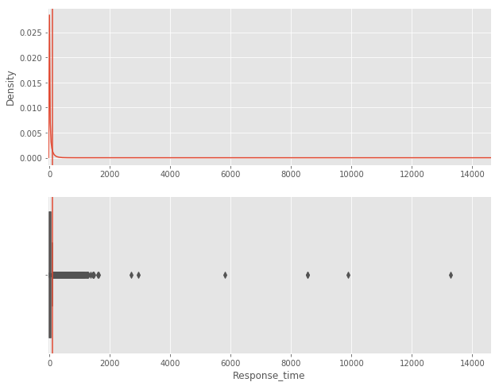

```python
#------------------------------------------------------
# Plot IQR for Response Time - 25th and 75th quartiles
#------------------------------------------------------
q75, q25 = np.percentile(incident.Response_time.dropna(), [75 ,25])

#--------------------
# Calculate the IQR
#--------------------
iqr = q75 - q25

#-----------------------------------------------------
# Establish the limits for the outliers using the IQR
#-----------------------------------------------------
min = q25 - (iqr*1.5)
max = q75 + (iqr*1.5)

print('Minimum Outlier Threshold Value: ',min)
print('Maximum Outlier Threshold Value: ',max)

#---------------------------------
# Index the Response_Time attribute
#---------------------------------
index = 'Response_time'

#--------------------------------------------------------------------------------------------------
# Plot the Response_Time attribute before the removal of outliers with a kernel density estimation
#--------------------------------------------------------------------------------------------------
plt.figure(figsize=(10,8))
plt.subplot(211)
plt.xlim(incident[index].min(), incident[index].max()*1.1)
plt.axvline(x=min)
plt.axvline(x=max)

# Add a kernel density estimation
ax = incident[index].plot(kind='kde')

#---------------------------------------------
# Add a Box plot to further identify outliers
#---------------------------------------------
plt.subplot(212)
plt.xlim(incident[index].min(),incident[index].max()*1.1)
sns.boxplot(x=incident[index])
plt.axvline(x=min)
plt.axvline(x=max)
```

**Since the Minimum Outlier Threshold value is negative which does not make practical sense, we will set the minimum value to 0**

The Maximum Outlier Threshold value is computed as **97**

- As is evident from a visual inspection of the plots above, there are clear outliers in the Response_Time attribute

```python
#------------------------------------------------------------------------------
# We will add a new column for outliers and initialize all rows with a O value
#------------------------------------------------------------------------------
incident['Outlier'] = 0

#---------------------------------------------------------------------------------
# Let's Update the outlier column to value=1 when the response_time is an outlier
#---------------------------------------------------------------------------------
incident.loc[incident[index] <   0, 'Outlier'] = 1
incident.loc[incident[index] > max, 'Outlier'] = 1

#--------------------------------------------
# Let's count the number of outliers
#--------------------------------------------
incident[incident.Outlier==1].Outlier.count()
```

```
52127
```

```python
#------------------------------------------------------------------------
# We will filter out the outliers using the Outlier column where value=1
#------------------------------------------------------------------------
incident = incident[incident['Outlier']==0]

incident= incident.drop(['Outlier'],1)
```

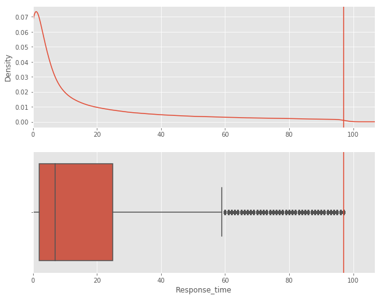

```python
#----------------------------------------------------------------------------------------------------------------
# Re-Plot the Response_Time attribute with a kernel density estimation to validate that the outliers are removed
#----------------------------------------------------------------------------------------------------------------
plt.figure(figsize=(10,8))
plt.subplot(211)
plt.xlim(incident[index].min(), incident[index].max()*1.1)
plt.axvline(x=min)
plt.axvline(x=max)

# Add a kernel density estimation
ax = incident[index].plot(kind='kde')

#------------------------------------------------------------
# Re-Plot the Box plot to reconfirm the removal of outliers
#------------------------------------------------------------
plt.subplot(212)
plt.xlim(incident[index].min(),incident[index].max()*1.1)
sns.boxplot(x=incident[index])
plt.axvline(x=min)
plt.axvline(x=max)
```

- As we can see, the Density Estimate plot and the box plot look much better after removal of the outliers

We will now run summary statistics on the Response_Time attribute to get a better representation

```python
incident['Response_time'].describe()
```

```
count    415884.000000
mean         17.362144
std          22.990615
min           0.000000
25%           2.000000
50%           7.000000
75%          25.000000
max          97.000000
Name: Response_time, dtype: float64
```

As is evident from the summary stats above:

- The Mean Response Time: **17.36** minutes
- The Minimum Response Time: **0** minute
- The Maximum Response Time: **97** minutes

# SIMPLE STATISTICS

The exploratory statistics on the Response_time calculated above proved to be more insightful since time and date alone were not adequate to answer the underlying questions of interest we had.

Per the Dallas Police Department, the trend of YTD average response times for priority 1 calls has decreased year over year from 2017 to 2018 YTD from 8.28 minutes to 8.13 minutes respectively.

(Source: https://www.dallaspolice.net/resources/CrimeReports/New%20Response%20Time%20Report.pdf)

We ran basic statistical summaries for non object or string datatypes. Based on the descriptive statistical summaries below we can observe the following.

```python
incident.select_dtypes(exclude=['object']).describe()
```

|  | Year_of_Incident | Watch | Reporting_Area | Beat | Sector | Victim_Age | Hate_Crime | Gang_Related_Offense | Drug_Related | UCR_Code | X_Coordinate | Y_Coordinate | Zip_Code | Response_time | Arrest_status |
| --- | --- | --- | --- | --- | --- | --- | --- | --- | --- | --- | --- | --- | --- | --- | --- |
| count | 417782.000000 | 417782.000000 | 417260.000000 | 417573.000000 | 417582.000000 | 255872.000000 | 417782.000000 | 417782.000000 | 417782.000000 | 380064.000000 | 3.713470e+05 | 3.713470e+05 | 417782.000000 | 415884.000000 | 417782.000000 |
| mean | 2016.155234 | 1.785773 | 3132.071804 | 415.973027 | 412.029829 | 39.591464 | 0.000184 | 0.003698 | 0.030102 | 1555.766476 | 2.494605e+06 | 6.978108e+06 | 74641.436749 | 17.362144 | 0.149233 |
| std | 1.307749 | 0.997284 | 1819.429349 | 196.735681 | 196.827312 | 15.335514 | 0.013575 | 0.060700 | 0.170868 | 1286.517205 | 2.212399e+04 | 3.143422e+04 | 6598.489608 | 22.990615 | 0.356319 |
| min | 2014.000000 | 0.000000 | 1001.000000 | 111.000000 | 0.000000 | -9.000000 | 0.000000 | 0.000000 | 0.000000 | 110.000000 | 2.411659e+06 | 6.889043e+06 | 0.000000 | 0.000000 | 0.000000 |
| 25% | 2015.000000 | 1.000000 | 1246.000000 | 241.000000 | 240.000000 | 27.000000 | 0.000000 | 0.000000 | 0.000000 | 630.000000 | 2.478266e+06 | 6.954852e+06 | 75214.000000 | 2.000000 | 0.000000 |
| 50% | 2016.000000 | 2.000000 | 3058.000000 | 417.000000 | 410.000000 | 37.000000 | 0.000000 | 0.000000 | 0.000000 | 710.000000 | 2.493360e+06 | 6.975216e+06 | 75224.000000 | 7.000000 | 0.000000 |
| 75% | 2017.000000 | 3.000000 | 4323.000000 | 553.000000 | 550.000000 | 50.000000 | 0.000000 | 0.000000 | 0.000000 | 2600.000000 | 2.507373e+06 | 7.001809e+06 | 75236.000000 | 25.000000 | 0.000000 |
| max | 2018.000000 | 3.000000 | 9611.000000 | 757.000000 | 750.000000 | 950.000000 | 1.000000 | 1.000000 | 1.000000 | 5700.000000 | 2.595095e+06 | 7.083051e+06 | 97224.000000 | 97.000000 | 1.000000 |

These are the numeric attributes we can used for our analysis.

```python
incident.dropna().groupby(['Year_of_Incident'])['Response_time'].median()
```

```
Year_of_Incident
2014    5.0
2015    5.0
2016    4.0
2017    5.0
2018    5.0
Name: Response_time, dtype: float64
```

We didn't see much difference on the median of the response time in each year. The Dallas city police department has maintained consistency on the response times.

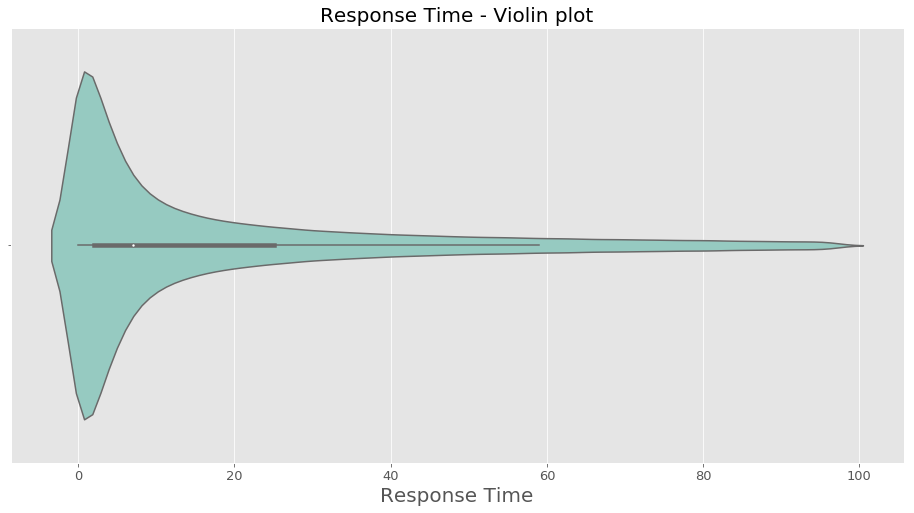

```python
#------------------------------------------------------------
# we can compare which one is better.
#------------------------------------------------------------
plt.figure(figsize=(16,8))
rt = sns.violinplot(x=incident["Response_time"]
                   ,palette = 'Set3')
rt.axes.set_title("Response Time - Violin plot",fontsize=20)
rt.set_xlabel("Response Time",fontsize=20)
rt.tick_params(labelsize=13)
plt.show()
```

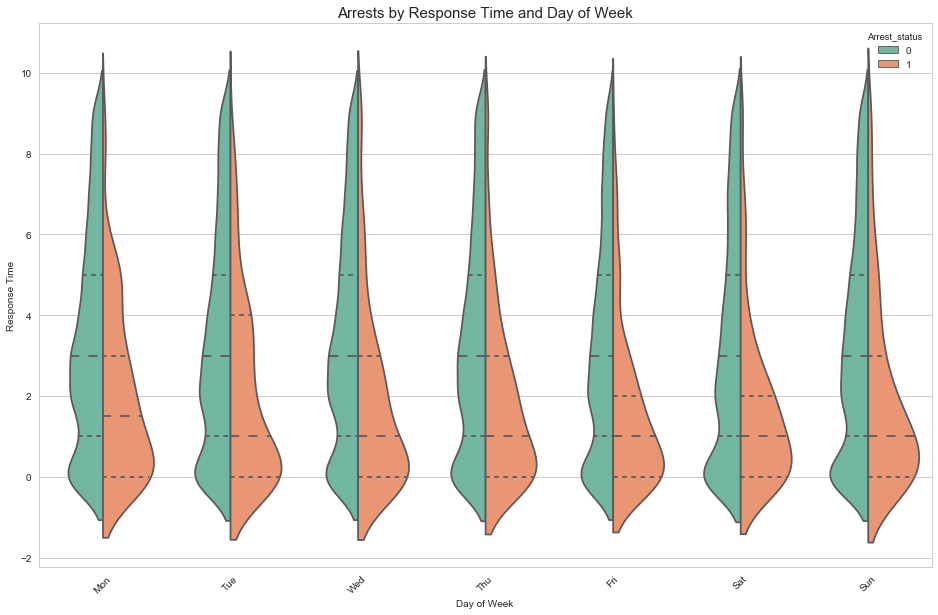

```python
#------------------------------------------------------------
# Get the highest frequency offense and do violin plot
#------------------------------------------------------------
plt.figure(figsize=(16,10))

highest_inc = incident[incident['UCR_Offense_Name']=='THEFT/BMV'][incident['Response_time']<10]

sns.set(style="whitegrid")
ax = sns.violinplot(x= 'Day1_of_the_Week'
                   ,y='Response_time'
                   ,hue='Arrest_status'
                   ,order=['Mon','Tue','Wed','Thu','Fri','Sat','Sun']
                   ,palette='Set2'
                   ,split=True
                   ,inner='quartile'
                   ,data = highest_inc)
ax.set_xticklabels(ax.get_xticklabels(),rotation=45)
ax.axes.set_title("Arrests by Response Time and Day of Week",fontsize=15)
ax.set_xlabel("Day of Week",fontsize=10)
ax.set_ylabel("Response Time",fontsize=10)
ax.tick_params(labelsize=10)
```

This violin plot indicates the response time distribution for the THEFT/BMV (Burglary Motor Vehicle) offense. The violin plot shows the relationship between the response time and the day of the week as well as the arrest status.

```python
incident.fillna(0).groupby(['Division'])['Victim_Age'].mean()
```

```
Division
CENTRAL          21.723958
NORTH CENTRAL    26.041763
NORTHEAST        25.482338
NORTHWEST        22.923725
SOUTH CENTRAL    25.074179
SOUTHEAST        24.929715
SOUTHWEST        23.878329
Unknown          13.746411
Name: Victim_Age, dtype: float64
```

# VISUALIZE ATTRIBUTES

To better understand and represent key findings we used graphical components from pandas, matlab, PixieDust and even Power BI. This enabled a much richer presentation of the facts and findings. We selected the following attributes to visualize since they provided greater insight into crime patterns by location and time, victim profiles, arrests and the effect of response time.

- **Victim Type:** Victim type by incident count. This was best represented using a horizontal barchart.
- **Arrest Status:** Arrests made against incidents reported and investigated. This was best represented using a horizontal barchart.
- **Watch:** Categorizes which shifts or watch had the most reported incidents in the day.It is evident from the visual that Late night incidents are the highest followed by Evenings and Day.
- **Calls Received by hour:** This is a distribution of incidents reported by hour of day and provides greater understanding of when the most incidents are received. It enables better planning of resources at the respective divisions.
- **Division:** Incidents by Police Division gave insight into which areas in Dallas have the highest reported incidents

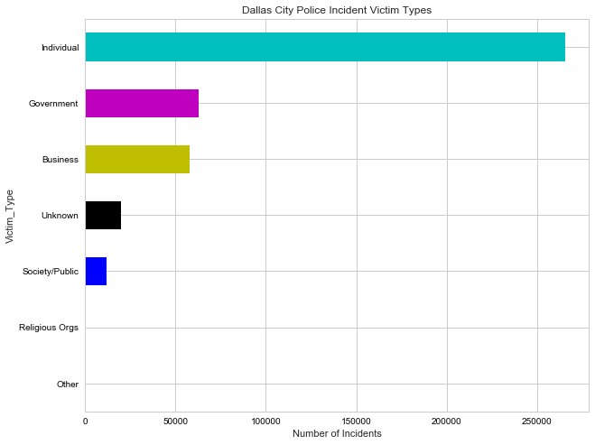

```python
#------------------------------------------------------
# get the incident number by victim type data set
#------------------------------------------------------
vt = incident.fillna('Unknown').groupby(['Victim_Type'])['Service_Number_ID'].count().sort_values()
plt.figure(figsize=(10,8))

#------------------------------------------------------
#Set descriptions:
#------------------------------------------------------
plt.title("Dallas City Police Incident Victim Types")
plt.ylabel('Victim Type')
plt.xlabel('Number of Incidents')

#------------------------------------------------------
#Set tick colors:
#------------------------------------------------------
ax = plt.gca()
ax.tick_params(axis='x', colors='black')
ax.tick_params(axis='y', colors='black')

#------------------------------------------------------
#Plot the data:
#------------------------------------------------------
my_colors ='rgbkymc'   #red, green, blue, black, etc.
#my_colors = ['r','g','b','k','y','m','c']

vt.plot(kind='barh', color=my_colors)

plt.show()
```

- **Victim Type:** Victim type by incident count. This was best represented using a horizontal barchart.

From the above plot, we can see that the **most common victim type** is **Individuals** followed by **Government** and **Business Institutions**.

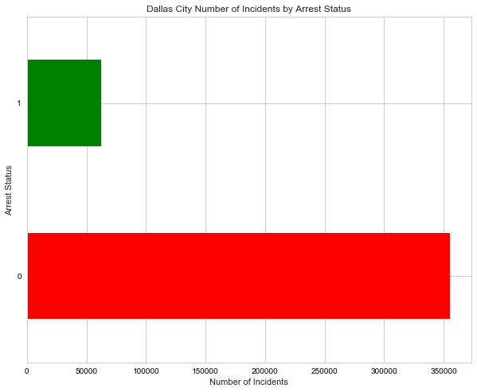

```python
#------------------------------------------------------
# Get incident counts by arrest status
#------------------------------------------------------
ars = incident['Arrest_status'].value_counts()
plt.figure(figsize=(10,8))

#------------------------------------------------------
#Set descriptions:
#------------------------------------------------------
plt.title("Dallas City Number of Incidents by Arrest Status")
plt.ylabel('Arrest Status')
plt.xlabel('Number of Incidents')

#------------------------------------------------------
#Set tick colors:
#------------------------------------------------------
ax = plt.gca()
ax.tick_params(axis='x', colors='black')
ax.tick_params(axis='y', colors='black')

#------------------------------------------------------
#Plot the data:
#------------------------------------------------------
my_colors ='rgbkymc'   #red, green, blue, black, etc.
# my_colors = ['r','g','b','k','y','m','c'] # you may want to change to this is the color is not working on your computer
ars.plot(kind='barh', color=my_colors,)

plt.show()
```

LEGEND:

- GREEN (1): Arrest made
- RED (0): No arrest made
- **Arrest Status:** Arrests made against incidents reported and investigated. This was best represented using a horizontal barchart.

It is evident from the above plot that while there were many reported incidents, actual arrests occured in about 16% of the reported incidents.

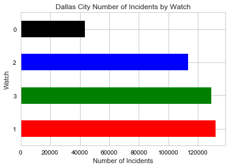

```python
#------------------------------------------------------------------------
# Get incident counts by watch
#------------------------------------------------------------------------
wt = incident['Watch'].value_counts()

#------------------------------------------------------------------------
#Set descriptions:
#------------------------------------------------------------------------
plt.title("Dallas City Number of Incidents by Watch")
plt.ylabel('Watch')
plt.xlabel('Number of Incidents')

#------------------------------------------------------------------------
#Set tick colors:
#------------------------------------------------------------------------
ax = plt.gca()
ax.tick_params(axis='x', colors='black')
ax.tick_params(axis='y', colors='black')

#------------------------------------------------------------------------
#Plot the data:
#------------------------------------------------------------------------
my_colors ='rgbkymc'   #red, green, blue, black, etc.
# my_colors = ['r','g','b','k','y','m','c']  #red, green, blue, black, etc.

wt.plot(kind='barh', color=my_colors,)

plt.show()
```

**Watch Timings**

- 1st watch = Late Night (12am-8am)
- 2nd watch = Days (8am-4pm)
- 3rd watch = Evenings (4pm-12am)
- Watch category 0 are unknown and a result of missing data
- **Watch:** Categorizes which shifts or watch had the most reported incidents in the day.It is evident from the visual that Late night incidents are the highest followed by Evenings and Day.

Above we see the trend of the **number of incidents reported by the watch schedule** of the responding officer. Below, we look at another view of this visual that shows us the **number of calls received by hour**.

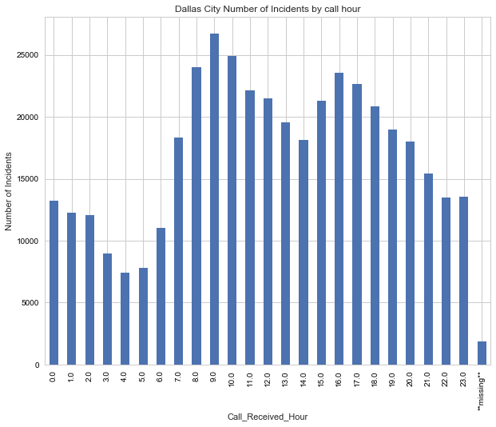

```python
#------------------------------------------------------------------------
# create new column for call received hour
#------------------------------------------------------------------------
incident['Call_Received_Hour']=pd.to_datetime(incident['Call_Received_Date_Time'].dropna()).dt.hour.astype(int)

#------------------------------------------------------------------------
# get incident count by call received hours
#------------------------------------------------------------------------
crh = incident.fillna('**missing**').groupby('Call_Received_Hour')['Service_Number_ID'].count()
plt.figure(figsize=(10,8))

#------------------------------------------------------------------------
#Set descriptions:
#------------------------------------------------------------------------
plt.title("Dallas City Number of Incidents by call hour")
plt.ylabel('Number of Incidents')
plt.xlabel('Hours')

#------------------------------------------------------------------------
#Set tick colors:
#------------------------------------------------------------------------
ax = plt.gca()
ax.tick_params(axis='x', colors='black')
ax.tick_params(axis='y', colors='black')

#------------------------------------------------------------------------
#Plot the data:
#------------------------------------------------------------------------
crh.plot(kind='bar')

plt.show()
```

Above bar chart indicates that most of the incidents are reported around 9:00 AM. We notice another peak around 4:00 PM. This could be a trend because this is the peak commute time.

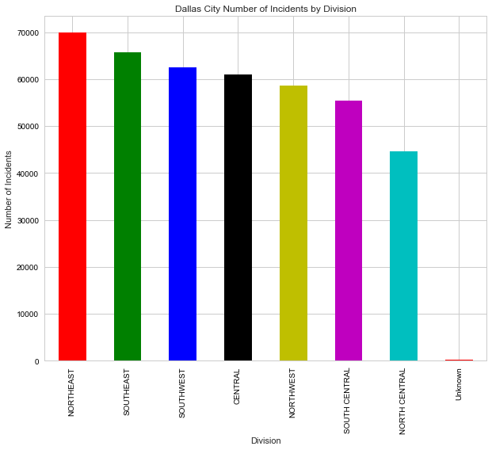

```python
#------------------------------------------------------------------------
# get the incident counts for each division
#------------------------------------------------------------------------
dv =incident['Division'].fillna('***MISSING***').value_counts()
plt.figure(figsize=(10,8))

#------------------------------------------------------------------------
#Set descriptions:
#------------------------------------------------------------------------
plt.title("Dallas City Number of Incidents by Division")
plt.ylabel('Number of Incidents')
plt.xlabel('Division')

#------------------------------------------------------------------------
#Set tick colors:
#------------------------------------------------------------------------
ax = plt.gca()
ax.tick_params(axis='x', colors='black')
ax.tick_params(axis='y', colors='black')

#------------------------------------------------------------------------
#Plot the data:
#------------------------------------------------------------------------
my_colors ='rgbkymc'   #red, green, blue, black, etc.
# my_colors = ['r','g','b','k','y','m','c'] # you may want to change to this is the color is not working on your computer

dv.plot(kind='bar', color=my_colors,)

plt.show()
```

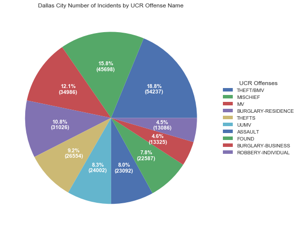

```python
uon = incident['UCR_Offense_Name'].value_counts().sort_values(ascending=[False]).head(10)
fig, ax = plt.subplots(figsize=(10, 8), subplot_kw=dict(aspect="equal"))

recipe = ["THEFT/BMV",
"VANDALISM & CRIM MISCHIEF", #   42009
"ACCIDENT MV",#                  28534
"BURGLARY-RESIDENCE",  #         22264
"OTHER THEFTS ",     #           22191
"UUMV",             #            20723
"ASSAULT",          #            19898
"FOUND",            #           18268
"BURGLARY-BUSINESS", #           12598
"ROBBERY-INDIVIDUAL",]

ingredients = [x.split()[-1] for x in recipe]

def func(pct, allvals):
    absolute = int(pct/100.*np.sum(allvals))
    return "{:.1f}%\n({:d})".format(pct, absolute)


wedges, texts, autotexts = ax.pie(uon, autopct=lambda pct: func(pct, uon),
                                  textprops=dict(color="w"))

ax.legend(wedges, ingredients,
          title="UCR Offenses",
          loc="center left",
          bbox_to_anchor=(1, 0, 0.5, 1))

plt.setp(autotexts, size=11, weight="bold")

ax.set_title("Dallas City Number of Incidents by UCR Offense Name")

plt.show()
```

Next we look at the **distribution of UCR offences** for the top 10 categories. THEFT/BMV (Burglary Motor Vehicle) is the most commonly reported incident followed by Mischief. The top 5 categories are primarily around Theft/BMV, Mischief, Motor Vehicle, Residential Burglary and Thefts.

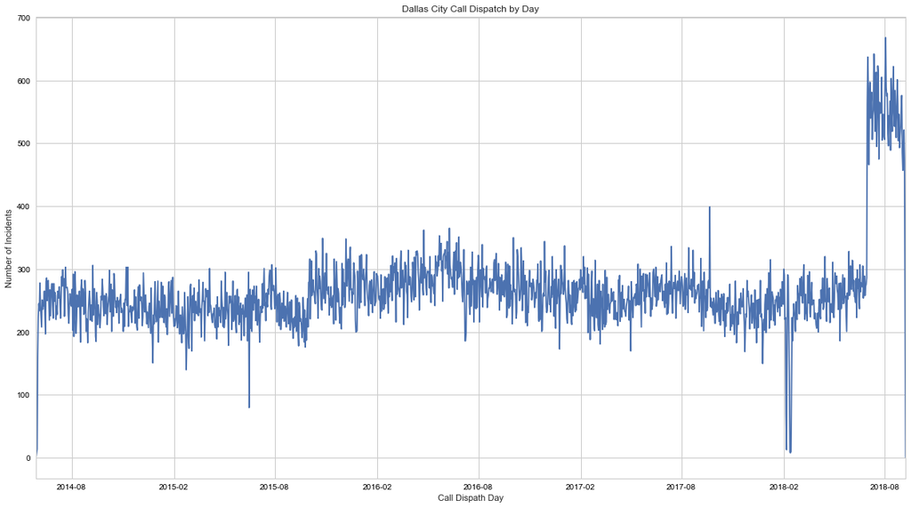

```python
#------------------------------------------------------------------------
# Call dispatch by month
#------------------------------------------------------------------------
cd =incident['Call_Dispatch'].dt.date.value_counts()
plt.figure(figsize=(16,9))

#------------------------------------------------------------------------
#Set descriptions:
#------------------------------------------------------------------------
plt.title("Dallas City Call Dispatch by Day")
plt.ylabel('Number of Incidents')
plt.xlabel('Call Dispath Day')

#------------------------------------------------------------------------
#Set tick colors:
#------------------------------------------------------------------------
ax = plt.gca()
ax.tick_params(axis='x', colors='black')
ax.tick_params(axis='y', colors='black')

#------------------------------------------------------------------------
#Plot the data:
#------------------------------------------------------------------------
cd.plot(kind='line')
plt.tight_layout()

plt.show()
```

```python
incident['Type_Location'].value_counts().head(10)
```

```
Highway, Street, Alley ETC            92370
Single Family Residence - Occupied    48205
Parking Lot (All Others)              41284
Apartment Parking Lot                 34569
Outdoor Area Public/Private           26647
Apartment Residence                   23183
Apartment Complex/Building            22695
Other                                 19865
Retail Store                          14426
Convenience Store                      9233
Name: Type_Location, dtype: int64
```

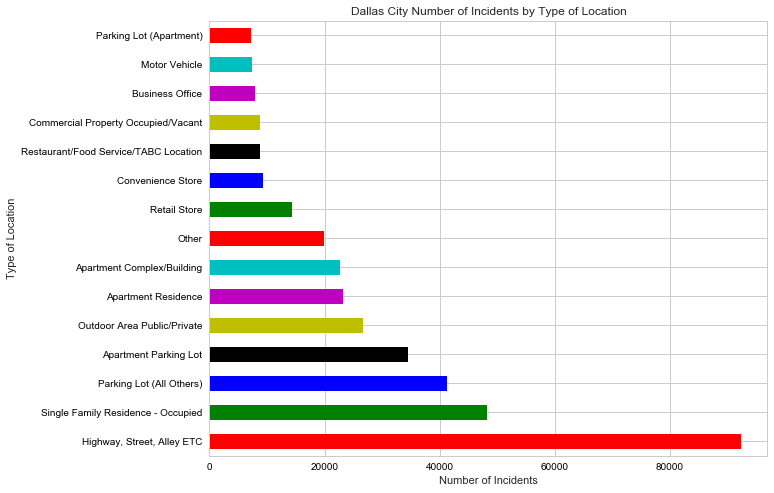

```python
#------------------------------------------------------------------------
# Get incident count by location type
#------------------------------------------------------------------------
tl = incident['Type_Location'].value_counts().head(15)
plt.figure(figsize=(10,8))

#------------------------------------------------------------------------
#Set descriptions:
#------------------------------------------------------------------------
plt.title("Dallas City Number of Incidents by Type of Location")
plt.ylabel('Type of Location')
plt.xlabel('Number of Incidents')

#------------------------------------------------------------------------
#Set tick colors:
#------------------------------------------------------------------------
ax = plt.gca()
ax.tick_params(axis='x', colors='black')
ax.tick_params(axis='y', colors='black')

#------------------------------------------------------------------------
#Plot the data:
#------------------------------------------------------------------------
my_colors ='rgbkymc'   #red, green, blue, black, etc.
# my_colors = ['r','g','b','k','y','m','c'] # you may want to change to this is the color is not working on your computer

tl.plot(kind='barh', color=my_colors,)

plt.show()
```

The above plot shows that most of the reported offenses occur on Highways, Streets and in Alleys followed by Single Family residences.

# EXPLORE JOINT ATTRIBUTES

Looking at response time across the years we see that response time seems to be reducing. This is a good metric for the community as it indicates the police are getting more responsive and also making more arrests since quicker response times are related to more arrests. This is a good trend for the Dallas police. We will analyze this in future projects to classify these response times as part of our classification analysis. We will conduct cross validations to further confirm our hypothesis.

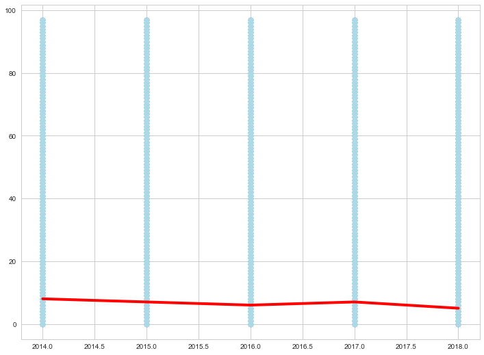

```python
plt.subplots(figsize = (12,9))
plt.scatter(incident['Year_of_Incident'].astype(str), incident['Response_time'], color='lightblue');
plt.plot(incident.groupby(['Year_of_Incident'])['Response_time'].median(), color = 'red', linewidth = 4)

plt.show()
```

```python
#------------------------------------------------------------------------
# CUSTOM VIRTUALIZATION DICTIONARY
#------------------------------------------------------------------------
def hover_to_see_data():
    '''Setting up the dictionary for selector and props for sns correlation plot table style'''
    return [dict(selector="th",
                 props=[("font-size", "8pt")]),
            dict(selector="td",
                 props=[('padding', "0em 0em")]),
            dict(selector="th:hover",
                 props=[("font-size", "12pt")]),
            dict(selector="tr:hover td:hover",
                 props=[('max-width', '200px'),
                        ('font-size', '12pt')])]

inci_numeric = incident.select_dtypes(exclude=['object'])
inciCorrMat = inci_numeric.corr()
inciCorrMat.style.background_gradient(sns.diverging_palette(240, 10, as_cmap=True), axis=1)\
    .set_properties(**{'max-width': '80px', 'font-size': '1pt'})\
    .set_caption("Correlation Heatmap for numeric variables")\
    .set_precision(2)\
    .set_table_styles(hover_to_see_data())
```

Correlation Heatmap for numeric variables

|  | Year_of_Incident | Watch | Reporting_Area | Beat | Sector | Victim_Age | Hate_Crime | Gang_Related_Offense | Drug_Related | UCR_Code | X_Coordinate | Y_Coordinate | Zip_Code | Response_time | Arrest_status | Call_Received_Hour |
| --- | --- | --- | --- | --- | --- | --- | --- | --- | --- | --- | --- | --- | --- | --- | --- | --- |
| Year_of_Incident | 1 | 0.027 | -0.003 | 0.0029 | 0.003 | 0.0078 | -0.0015 | -0.014 | 0.042 | 0.054 | -0.012 | -0.007 | 0.058 | -0.048 | 0.059 | -0.011 |
| Watch | 0.027 | 1 | 0.0084 | 0.0046 | 0.0045 | -0.062 | 0.0052 | 0.018 | 0.072 | 0.11 | 0.027 | -0.027 | -0.011 | -0.055 | 0.12 | 0.53 |
| Reporting_Area | -0.003 | 0.0084 | 1 | 0.36 | 0.36 | -0.0062 | -0.0037 | -0.0059 | -0.0064 | -0.014 | -0.35 | -0.14 | -0.0011 | 0.0025 | 0.0077 | 0.007 |
| Beat | 0.0029 | 0.0046 | 0.36 | 1 | 1 | 0.051 | -0.005 | -0.0001 | -0.016 | -0.017 | -0.41 | -0.12 | -0.0005 | 0.0051 | -0.013 | 0.0078 |
| Sector | 0.003 | 0.0045 | 0.36 | 1 | 1 | 0.051 | -0.005 | -0.00014 | -0.016 | -0.017 | -0.41 | -0.12 | -0.0005 | 0.005 | -0.012 | 0.0077 |
| Victim_Age | 0.0078 | -0.062 | -0.0062 | 0.051 | 0.051 | 1 | -0.0022 | -0.022 | -0.023 | 0.069 | 0.014 | -0.023 | -0.00074 | 0.01 | -0.043 | -0.0057 |
| Hate_Crime | -0.0015 | 0.0052 | -0.0037 | -0.005 | -0.005 | -0.0022 | 1 | 0.0021 | -0.0024 | -0.0093 | 0.0017 | 0.0026 | -0.017 | -0.0055 | 0.011 | 0.0045 |
| Gang_Related_Offense | -0.014 | 0.018 | -0.0059 | -0.0001 | -0.00014 | -0.022 | 0.0021 | 1 | 0.055 | -0.0053 | 0.015 | -0.0038 | -0.016 | -0.024 | 0.025 | 0.016 |
| Drug_Related | 0.042 | 0.072 | -0.0064 | -0.016 | -0.016 | -0.023 | -0.0024 | 0.055 | 1 | 0.14 | 0.019 | -0.015 | -0.0044 | -0.087 | 0.16 | 0.028 |
| UCR_Code | 0.054 | 0.11 | -0.014 | -0.017 | -0.017 | 0.069 | -0.0093 | -0.0053 | 0.14 | 1 | 0.0025 | -0.024 | 0.0098 | -0.12 | -0.056 | 0.0075 |
| X_Coordinate | -0.012 | 0.027 | -0.35 | -0.41 | -0.41 | 0.014 | 0.0017 | 0.015 | 0.019 | 0.0025 | 1 | 0.02 | 0.0035 | -0.01 | -0.0064 | 0.017 |
| Y_Coordinate | -0.007 | -0.027 | -0.14 | -0.12 | -0.12 | -0.023 | 0.0026 | -0.0038 | -0.015 | -0.024 | 0.02 | 1 | 0.013 | 0.011 | -0.013 | 0.00087 |
| Zip_Code | 0.058 | -0.011 | -0.0011 | -0.0005 | -0.0005 | -0.00074 | -0.017 | -0.016 | -0.0044 | 0.0098 | 0.0035 | 0.013 | 1 | 0.014 | -0.045 | -0.0093 |
| Response_time | -0.048 | -0.055 | 0.0025 | 0.0051 | 0.005 | 0.01 | -0.0055 | -0.024 | -0.087 | -0.12 | -0.01 | 0.011 | 0.014 | 1 | -0.14 | 0.061 |
| Arrest_status | 0.059 | 0.12 | 0.0077 | -0.013 | -0.012 | -0.043 | 0.011 | 0.025 | 0.16 | -0.056 | -0.0064 | -0.013 | -0.045 | -0.14 | 1 | 0.024 |
| Call_Received_Hour | -0.011 | 0.53 | 0.007 | 0.0078 | 0.0077 | -0.0057 | 0.0045 | 0.016 | 0.028 | 0.0075 | 0.017 | 0.00087 | -0.0093 | 0.061 | 0.024 | 1 |

The above heat map shows the correlation between attributes. This visual clearly differentiates highly correlated attributes from those less correlated.

```python
corrPairs = inciCorrMat.unstack().sort_values(kind="quicksort")
corrPairs = corrPairs[::2]
corrPairs = corrPairs[corrPairs.index.get_level_values(0) != corrPairs.index.get_level_values(1)]
with pd.option_context('display.max_rows',32):
    print(corrPairs)
```

```
Sector                X_Coordinate         -0.413385
Beat                  X_Coordinate         -0.411158
Reporting_Area        X_Coordinate         -0.353199
                      Y_Coordinate         -0.144696
Arrest_status         Response_time        -0.135933
UCR_Code              Response_time        -0.121131
Y_Coordinate          Beat                 -0.118212
Sector                Y_Coordinate         -0.116607
Response_time         Drug_Related         -0.087050
Victim_Age            Watch                -0.061697
Arrest_status         UCR_Code             -0.056301
Response_time         Watch                -0.054890
                      Year_of_Incident     -0.048219
Arrest_status         Zip_Code             -0.045459
                      Victim_Age           -0.042965
Watch                 Y_Coordinate         -0.027236
                                              ...
Victim_Age            Beat                  0.050995
UCR_Code              Year_of_Incident      0.054146
Gang_Related_Offense  Drug_Related          0.054810
Zip_Code              Year_of_Incident      0.058017
Arrest_status         Year_of_Incident      0.059266
Response_time         Call_Received_Hour    0.061019
UCR_Code              Victim_Age            0.069080
Watch                 Drug_Related          0.071710
                      UCR_Code              0.112438
                      Arrest_status         0.123599
UCR_Code              Drug_Related          0.144939
Arrest_status         Drug_Related          0.163794
Reporting_Area        Beat                  0.358394
                      Sector                0.358519
Watch                 Call_Received_Hour    0.530307
Beat                  Sector                0.999944
Length: 120, dtype: float64
```

- Division: Dallas Partrol divisions including Centrol, North Central, Northeast, Northwest, South Central, Southeast, Southwest, and Headquarters.
- Sector is an approach to policing whereby the service area of a police station is divided into smaller, manageable areas known as sectors. For each sector, the SAPS appoint a police official who is known as the sector commander.
- Beat is the territory and time that a police officer patrols.Beat policing is based on traditional policing (late 19th century) and utilises the close relationship with the community members within the assigned beat to strengthen police effectiveness and encourage cooperative efforts to make a safer community. Beat police typically patrol on foot or bicycle which provides more interaction between police and community members.
- Reporting Area: Each Beat contains neighborhoods which are referred to as Reporting Areas.
- Here is the detail about how Dallas city police department is divided by council district, division, sector, beat and Reporting Area http://www.dallaspolice.net/abouts/maps

We also observe the following correlations:

- Watch or shift is highly correlated with Calls received by hour as we have observed previously in our prior visualization.
- Arrest status is also correlated to response time which we have highlighted above, but will further analyze below so the impact of early response time to arrests is confirmed.

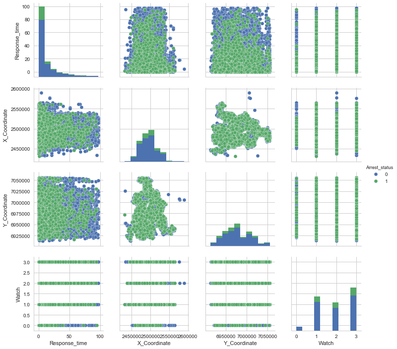

```python
sns.pairplot(incident.dropna()
             , vars=['Response_time', 'X_Coordinate', 'Y_Coordinate','Watch']
             , hue='Arrest_status')
```

Legend

- GREEN (1): represents the arrest made during response to the incident which are closely clustered with lower respose time.
- BLUE (0): represents arrests not made and aligns with higher response times

The columns with highest importance relate to response time.

The arrest is more likely when the response time is quicker, which is supported from other visualizations as well.

Late night crimes are more prevalent and frequent as per data which is a generally accepted norm as per social dynamics. Criminals clearly prefer the late and early hours of the day for criminal activity probably because since there are fewer people around and less daylight.

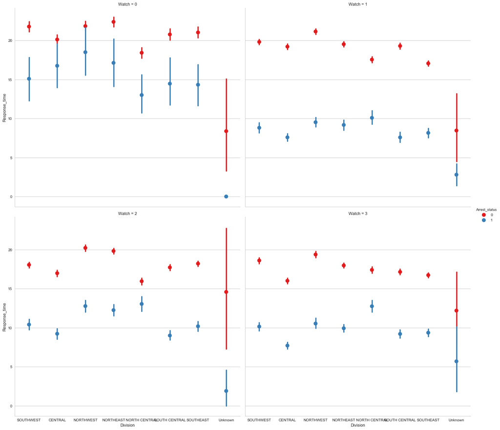

```python
sns.factorplot(x="Division"
              ,y="Response_time"
              ,hue="Arrest_status"
              ,col="Watch"
              ,data=incident
              ,join= False
              ,palette="Set1"
              ,size=8
              ,aspect=1.1
              ,col_wrap=2)
plt.show()
```

- The above visual plots the Response time by Division for different values of Watch (0-3).
- From the plots above, it does not seem as though there is a significant relationship between response time and time of the day on arrest being made.

Response times are pretty similar across watch 1, 2 and 3 for all divisions.

0 - Unknown Watch Category. Data on the Watch schedule of the responding officer was missing for some records. We have currently defaulted them to 0 (Unknown).

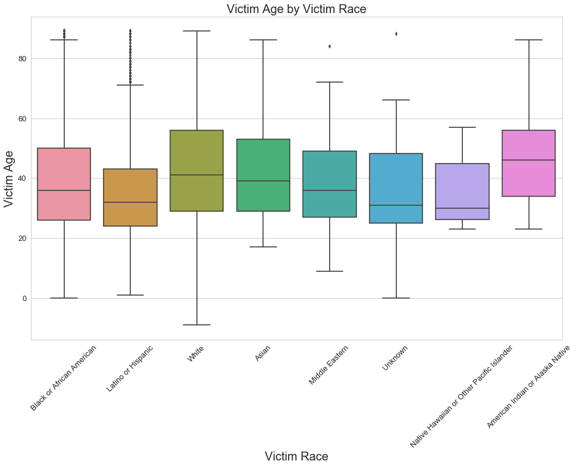

```python
plt.figure(figsize=(16,10))

incident= incident[incident['Victim_Age']<90]
va = sns.boxplot(x='Victim_Race'
                ,y='Victim_Age'
                ,data=incident.dropna())
va.set_xticklabels(va.get_xticklabels(),rotation=45)
va.axes.set_title("Victim Age by Victim Race",fontsize=20)
va.set_xlabel("Victim Race",fontsize=20)
va.set_ylabel("Victim Age",fontsize=20)
va.tick_params(labelsize=13)
```

**Average life expectancy in Texas is 77.4yrs and the overall US life expectancy is 78.7yrs**. Median age is fairly consistent across races between 30s-40s

*(Source: https://www.dshs.texas.gov/CHS/VSTAT/latest/nmortal.shtm)*

### 2017

- Please see below map report for the dallas crime distribute by zip code in 2017. The more read means more crime. Zip code 75217 has the most crime in 2017 (6027 incident calls) and zip code 75115 has the least crime (only 1 incident report in 2017).
- Please see the same map for 2016. You can see some minor changes on the edge of the county in 2017. The city may want to assign more police in these areas.

[figure not shown]

### 2016

[figure not shown]

## Explore Attributes and Class

Relationships Attributes we selected effect of Response time, arrests made Drug related incidents Response time - will be classified into categories such as good, bad and less than 30 minutes to help the police dept. better manage resources in the process of dealing with incidents

Attributes like drug related incidents, gang incidents, hate crimes to develop a scoring methodology for resource allocation by looking at other variables and dynamics of arrests made

We will use random forests classifier algorithms to assist in our analysis

## New Features

- Response time
  - This is the time between receiving the call and dispatching it to officers for investigation
- Arrest status
  - We have obtained the Police Arrests data set to enable more in-depth analysis.
- Latitude, Longitude
  - We could utilize the latitude and longtitude data to plot more accurate map of incidents by division / sector / beat.
- In future, we are looking to add more classification attributes.
- Social Crime - Once we develop the scoring methodology, this variable will be created to score incidents based on gang related, drugs, hate etc.
  - We could use the victim information to build the social crime profile.

## Exceptional Work

To complement our Police Incident dataset we imported the following datasets to provide greater insight for our analysis. This enabled us to better understand arrest rates against incidents as well as consider population factors that may play a critical role in effective policing of a large metropolitan city like DALLAS.

- **Police Arrests dataset**
- **Population Density dataset**

We also Geo-Mapped the data using Zip codes in Power BI to provide an enhanced visualization of crime pockets in the Dallas area.

Our research found that there are two categories of offenses reported in the NIBRS: Group A and Group B. It is important to determine which category an offense belongs to because the reporting requirements for Group A offenses and Group B offenses are different. Group A offenses are used to report all incidents committed within a law enforcement agency’s jurisdiction to the NIBRS, whereas Group B offenses are used only to report arrest data. The following criteria were used to determine if a crime should be designated as a Group A offense:

- The seriousness or significance of the offense.
- The frequency or volume of its occurrence.
- The prevalence of the offense nationwide.
- The probability of the offense being brought to law enforcement’s attention.
- The likelihood that law enforcement is the best channel for collecting data regarding the offense.
- The burden placed on law enforcement to collect data on the offense.
- The national statistical validity and usefulness of the collected data.
- The FBI UCR Program’s responsibility to make crime data available not only to law enforcement but to others having a legitimate interest in it.

There are 22 Group A offense categories making up 46 Group A offenses. Each offense’s corresponding UCR Offense Code precedes its name. Immediately following the name of each offense name is an indication of whether it involves a Crime Against Person, Crime Against Property, or Crime Against Society.

There are 11 Group B offense categories. They encompass all of the crimes that are not Group A offenses.

(Source:FBI.gov) )

- Deletion and imputation
  - We did not delete any data but excluded NULL values in some of the visualizations. Given most of the data in the set was categorical we chose not to impute data as we had a very large dataset of 466K observations.

```python
# Our final dataset for future use
# incident_imputed = incident[['Year_of_Incident', 'Watch', 'Type_of_Incident',
#                            'Type_Location', 'Reporting_Area', 'Beat', 'Division', 'Sector',
#                            'Council_District', 'Day1_of_the_Week',
#                            'Person_Involvement_Type', 'Victim_Type', 'Victim_Race',
#                            'Victim_Gender', 'Victim_Age', 'Offense_Status', 'Victim_Condition',
#                            'Hate_Crime','Weapon_Used', 'Gang_Related_Offense',
#                            'Drug_Related_Istevencident', 'UCR_Offense_Name', 'RMS_Code',
#                            'UCR_Code', 'X_Coordinate', 'Y_Coordinate', 'Zip_Code', 'City', 'State',
#                            'Location1', 'Call_Received', 'Call_Cleared', 'Call_Dispatch',
#                            'Number_of_offense', 'Response_time', 'Latitude', 'Longitude',
#                            'Arrest_status', 'Call_Received_Hour']]
```

SOURCES:

- Reference: https://seaborn.pydata.org/generated/seaborn.violinplot.html
- Source: https://www.dshs.texas.gov/CHS/VSTAT/latest/nmortal.shtm)

  ```
            https://www.dallasopendata.com/Public-Safety/Police-Incidents/qv6i-rri7
            https://www.dallaspolice.net/resources/CrimeReports/New%20Response%20Time%20Report.pdf)
            https://ucr.fbi.gov/nibrs/2011/resources/nibrs-offense-codes
  ```